# A Report on Lake Ontario’s Microbes

Augustus Pendleton

2025-01-15

# Introduction

In this report, we will analyze how different water quality parameters affect the abundance of bacterial phyla.

# Set-up

## Loading Packages

First, we’ll load necessary packages:

```r
library(tidyverse)
```

## Reading in Data

Then, we’ll read in our data. We produced this dataframe by joining the sample_data.csv and taxon_abundance.csv files using an innerjoin.

```r
sample_and_taxon <- read_csv("data/sample_and_taxon.csv")
```

# Analyzing the Data

Finally, we’ll plot the relationship between temperature and overall microbial cell abundance.

[figure not shown]

```r
sample_and_taxon %>%
  ggplot() +
  aes(x = temperature,
      y = cells_per_ml/1e6,
      color = env_group) +
  geom_point() +
  labs(x = "Temperature (C)",
       y = "Cells (million/ml)",
       title = "Are temperature and cell abundance linked?")
```

It appears that wamer waters promote higher microbial cell counts. Cell counts were especially high in the warms waters of September.

The above plot shows 71 samples. For these samples, the minimum temp was 4C and the maximum was 20C.

| Statistic | Value |
| --- | --- |
| Number of Samples | 71 |
| Minimum Temp | 4 |
| Maximum Temp | 20 |

```r
library(knitr)
sample_and_taxon %>%
  filter(env_group == "Deep") %>%
  select(cells_per_ml, temperature, Chloroflexi) %>%
  kable()
```

| cells_per_ml | temperature | Chloroflexi |
| --- | --- | --- |
| 2058864 | 4.07380 | 0.1946356 |
| 2153086 | 4.66955 | 0.1306499 |
| 2293177 | 3.87050 | 0.1645819 |
| 2422141 | 3.76370 | 0.1617823 |
| 1847686 | 3.66830 | 0.2158370 |
| 1631065 | 3.67740 | 0.2272146 |
| 2270042 | 4.86530 | 0.1975365 |
| 1703592 | 4.19650 | 0.2464953 |
| 2304545 | 4.75550 | 0.0726973 |
| 1246414 | 3.97670 | 0.2593235 |
| 1793411 | 4.16960 | 0.1403407 |
| 1783244 | 5.26790 | 0.1406010 |
| 1989859 | 6.83795 | 0.1034825 |
| 1394350 | 3.83100 | 0.2504998 |
| 2067910 | 3.93275 | 0.1291681 |
| 1594241 | 3.77870 | 0.2420977 |
| 2008431 | 3.92295 | 0.1754827 |
| 1459993 | 3.76020 | 0.2423193 |
| 1852089 | 3.98550 | 0.1877596 |
| 1575429 | 4.02260 | 0.2308515 |
| 2024282 | 4.85345 | 0.1339617 |

1. *Markdown*
2. **facet_wrap**
3. *SQL*

[Markdown Tutorial](https://marschmilab.github.io/Cornell_Carpentries_Jan2025/05-r-markdown/index.html)

Challenge: Make a bullet point list. First line is your favorite coding language so far - in italics Second line is your favorite function we’ve learned so far - bold Third line is the next programming thing you want to learn - italics and bold

Switch to a numbered list Find a markdown formatting tutorial and insert it as a hyperlink

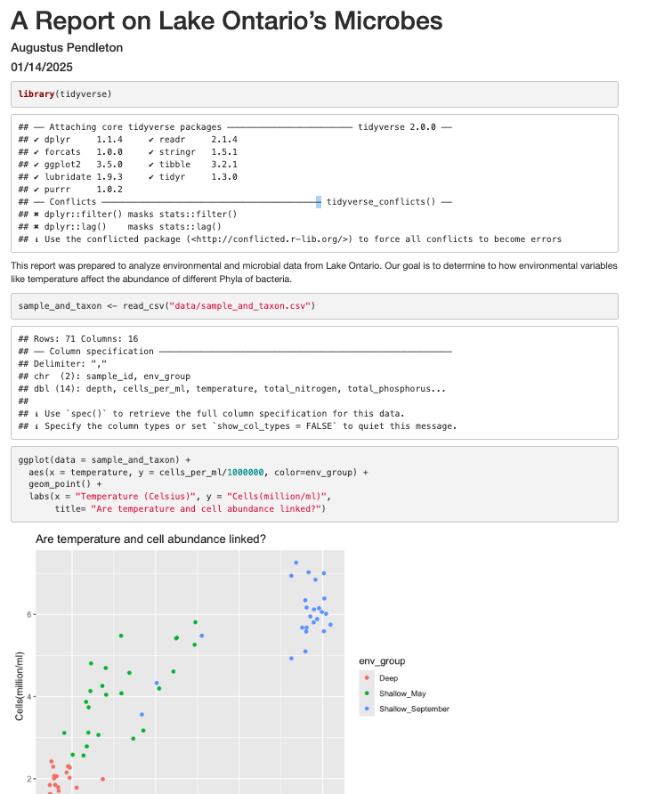

Schmidt et al. (2010)

Schmidt, S. K., R. C. Lynch, A. J. King, D. Karki, M. S. Robeson, L. Nagy, M. W. Williams, M. S. Mitter, and K. R. Freeman. 2010. “Phylogeography of Microbial Phototrophs in the Dry Valleys of the High Himalayas and Antarctica.” *Proceedings of the Royal Society B: Biological Sciences* 278 (1706): 702–8. https://doi.org/10.1098/rspb.2010.1254.